# IE 582 Homework 1

Yusuf Burak Ovali

Oct 18, 2018

# Assessing the Performance of Bookmakers

## Objective

The objective of this project is to assess the performances of the bookmakers who operate in English Premier League based on over and under odds by using specific bins. Two types of data are given at the beginning:

**1)** Actual match information with results between 2010 and 2018

**2)** Odd information of bookmakers for the matches given in the matches data

Firstly, for the Part 1 - Section A, five bookmakers are chosen and their performances are evaluated based on their implied probabilistic and actual empirical over fractions of matches. Since the odds are dynamic, only the initial and final odds are taken to make more reliable comments on their performances. 5 bookmakers are chosen as below:

**1)** **SBOBET**

**2)** **Tipico**

**3)** **bwin**

**4)** **12BET**

**5)** **Unibet**

Secondly, in the Part 1 - Section B, one bookmaker (SBOBET) is chosen and its initial odds for the matches are taken as primary data source and its performance over years is evaluated.

Lastly, in the Part 2, one bookmaker (SBOBET) is again chosen and the total number of changes in odds in each month is calculated. The reason for that is to support the hypothesis that in specific months, the bookmaker tends to change odds rapidly due to the increase in competition level and team adaptation periods.

## Part 1 - Section A - Performance of Bookmakers

To deal with large amount of data, make manipulations and plot the insights, data.table, anytime and ggplot packages are recalled.

```r
library(data.table)
library(ggplot2)
library(anytime)
```

To read data, readRDS function is used.

```r
matches_datapath='Desktop/df9b1196-e3cf-4cc7-9159-f236fe738215_matches-2.rds'
odd_details_datapath='Desktop/df9b1196-e3cf-4cc7-9159-f236fe738215_odd_details.rds'
matches=readRDS(matches_datapath)
odds=readRDS(odd_details_datapath)
```

To convert numerical date format to real date format and year in the matches data set, month and day information is splitted and kept under new columns.

```r
matches[,match_time:=anytime(date)]
matches[,Year:=year(match_time)]
matches[,Month:=month(match_time)]
matches[,Weekday:=wday(match_time)]
```

Same procedure is applied to results in order to quantify match result. For that purpose, total goals are calculated to understand whether the game result is under or over.

```r
matches[,c("HomeGoals","AwayGoals"):=tstrsplit(score,':')]
matches$HomeGoals=as.numeric(matches$HomeGoals)
matches[,AwayGoals:=as.numeric(AwayGoals)]
matches[,TotalGoals:=HomeGoals+AwayGoals]
```

To indicate the matches with under and over results, additional IsOver column is added. If total goals in the match is greater than two, the value in the cell will be 1, otherwise it remains as 0.

```r
matches[,IsOver:=0]
matches[TotalGoals>2,IsOver:=1]
```

Since the aim is to work on only over and under odds, the odds data table is filtered by betType and total handicap. After filtration, totalhandicap column is deleted since there is no need for it anymore.

The new odds data table is ordered by matchId, oddtype, bookmaker and date to have a better understanding of the data

```r
odds_over_under=odds[betType=='ou' & totalhandicap=='2.5']
odds_over_under[,totalhandicap:=NULL]
odds_over_under = odds_over_under[order(matchId, oddtype,bookmaker,date)]
```

The aim is to evaluate performances for the initial and final odds,so two different data tables are formed from the odds of under and over data set. To do that, for the initial odd, the first entry is taken. Since the data is ordered by date, the first entry gives the earliest one which means initial odd. Same procedure is followed to get final odds.

```r
odds_over_under_initial = odds_over_under [,list(first_odd = odd[1]),by = list(matchId,oddtype,bookmaker)]
odds_over_under_final = odds_over_under [, list (last_odd = odd[.N]), by = list (matchId,oddtype,bookmaker)]
```

To compare the implied probabilities of bookmakers and actual results of matches, odds of under and over results needs to be merged with matches data set which includes the actual results. Since their structures are different (odds data set is in tall format and matches data set is in wide format), the odds data set needs to be changed to the wide format. Dcast does this transformation.

The codes for initial and final odds comparison is same except using different source codes which are obtained above. So, only the codes for initial odds are provided beyond this point. In the dcast operation, the value of oddtypes (first odds in this case) are kept for both bookmaker and matchId because the matchId will be used as common variable in the merging operation and bookmakers will be used to evaluate performances of specific bookmakers. For these two variables, the value of oddtypes(first_odd in this case) is crucial.

```r
odds_over_under_initial_wide = dcast(odds_over_under_initial, bookmaker + matchId~oddtype , value.var='first_odd')
```

Merging operation between **matches** and **initial odds of under and over** is made as below. matchId are used in by statement, because both of the data sets have this variable and it has an important role as bridge between data sets.

```r
 merge_odds_match_i = merge(matches,odds_over_under_initial_wide,by = 'matchId')
```

Since the odds data set has only odds value not implied probabilities, there is need to calculate implied odds by using odds value. This action is made by dividing 1 over odds value and the sum of implied probabilities are expected to 1.

However, to make business more profitable, the bookmakers put some margin to the implied probabilities. Therefore, the sum of implied possibilities of results (over and under in this case) is higher than 1. Since sum of empirical over and under fractions are equal to 1 and each bookmaker puts different margin, the **normalization** needs to be applied to the implied possibilities as below:

```r
 merge_odds_match_i[,ProbOver:= 1/over]
 merge_odds_match_i[,ProbUnder:= 1/under]
 merge_odds_match_i[,TotalProb:= ProbOver + ProbUnder]
 merge_odds_match_i[,ProbOver:= ProbOver/TotalProb]
 merge_odds_match_i[,ProbUnder:= ProbUnder/TotalProb]
 merge_odds_match_i[,TotalProb:=NULL]
```

Since each bookmaker doesn’t offer odds for every match, some data points in the data set are NA. To tackle this problem, complete.cases function is recalled and all the rows with NA values in the odd column are removed.

```r
 merge_odds_match_i = merge_odds_match_i[complete.cases(merge_odds_match_i)]
```

There is going to be a comparison between empirical over fractions which depend on real scores and implied probabilities which depend on bookmakers’ work,so there should be specific intervals to discretize probability of over values into bins and calculate the number of games ended as ‘over’ in the corresponding bin.

The interval size is chosen as 0.04 and the bins are formed as below:

```r
 cutpoints=seq(0,1,0.04)
```

To assign over probabilities to the formed bins, the internal operation is made in merged data table as follows:

```r
 merge_odds_match_i = merge_odds_match_i[,odd_cut_over:= cut(ProbOver,cutpoints)]
```

To calculate the average of empirical over fractions and over probabilistic for the bins the codes are used as below:

```r
 summary_table_initial=merge_odds_match_i[,list(empirical_over = mean(IsOver),probabilistic_over = mean(ProbOver),.N), by=list(Year,odd_cut_over,bookmaker)]
 summary_table_initial=summary_table_initial[order(Year)]
```

While making comparison, there might be some not meaningful outliers because of the small size of bins. To avoid this, there is a need to detect bins with small sizes and merge these bins with others to increase the total number of observation. The procedure is applied as below:

```r
summary_table_initial_checkbin=merge_odds_match_i[,list(empirical_over = mean(IsOver),probabilistic_over = mean(ProbOver),.N), by=list(odd_cut_over,bookmaker)]
 SBOBET_sum_table_initial_checkbin = summary_table_initial_checkbin[bookmaker=='SBOBET']
```

**IMPORTANT NOTE:** Since the codes procedure is the same for all bookmakers, only the codes for bookmaker “SBOBET” is provided here and beyond. For the other bookmakers, user only needes to change the name of “SBOBET” with desired bookmaker name.

After examining the bins and their sizes, the bins that are needed to merged are determined. 30 is used as a threshold for the number of games. The bins with size less than 30 are merged. In that case, (0.56, 0.60] and (0.60, 0.64) bins are merged and the probabilities are reassigned to the new bins. The codes for that operation is showed below:

```r
SBOBET_cutpoints=cutpoints[-16]
SBOBET_cutpoints

SBOBET_merge_odds_match_i = merge_odds_match_i[bookmaker=='SBOBET']
SBOBET_merge_odds_match_i = SBOBET_merge_odds_match_i[,odd_cut_over:= cut(ProbOver,SBOBET_cutpoints)]

SBOBET_summary_table_initial=SBOBET_merge_odds_match_i[,list(empirical_over = mean(IsOver),probabilistic_over = mean(ProbOver),.N), by=list(odd_cut_over,bookmaker)]
SBOBET_summary_table_initial=SBOBET_summary_table_initial[order(odd_cut_over)]

SBOBET_summary_table_initial_checkbin=SBOBET_merge_odds_match_i[,list(empirical_over = mean(IsOver),probabilistic_over = mean(ProbOver),.N), by=list(odd_cut_over,bookmaker)]
```

**NOTE:** As mentioned above, the procedure for final odds are similar to initial odds except some character changes. So, the codes for final odds are not given here.

## Plots of the Selected Bookmakers

To assess the performances of bookmakers, the x=y line should be drawn. If the points appear on that line, it means the bookmaker’s odds are in line with the empirical fractions which means, the bookmaker makes great job on predicting the result of matches. For the points remain on the right handside of x=y line, the bookmaker gives higher odds than empirical probabilities which might affect its profitability in a bad way.

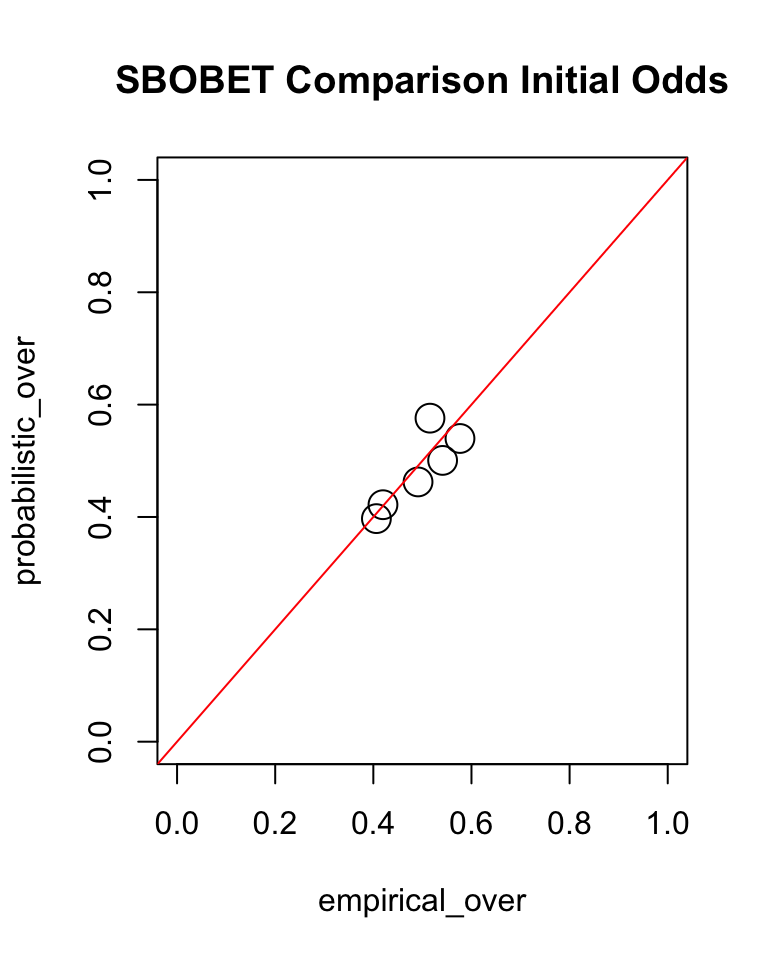

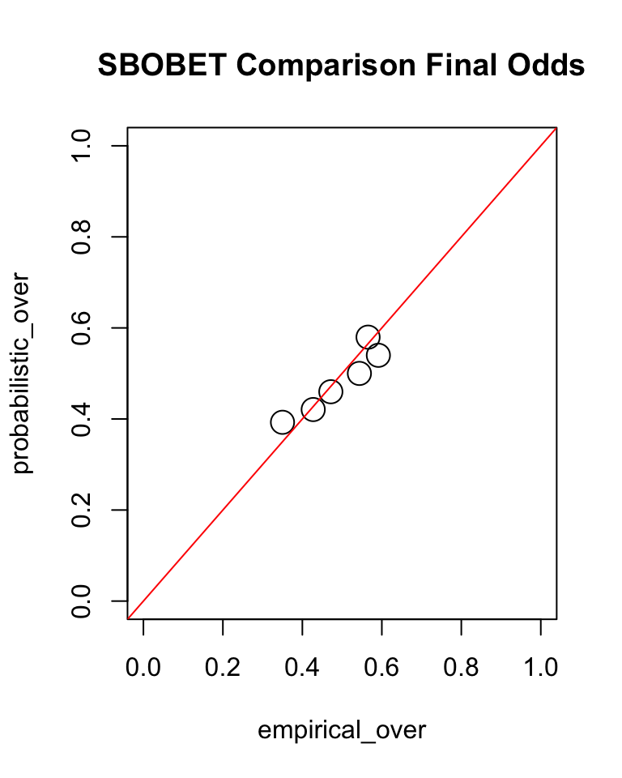

For the SBOBET, in the initial odds, the points are mostly in line with x=y line which means good. However, there are some points on the right handside which may decrease their profitability. On the other hand, in the final odds, there are more points on the line and other points are also closer to the x=y line. Therefore, the bookmaker makes better job.

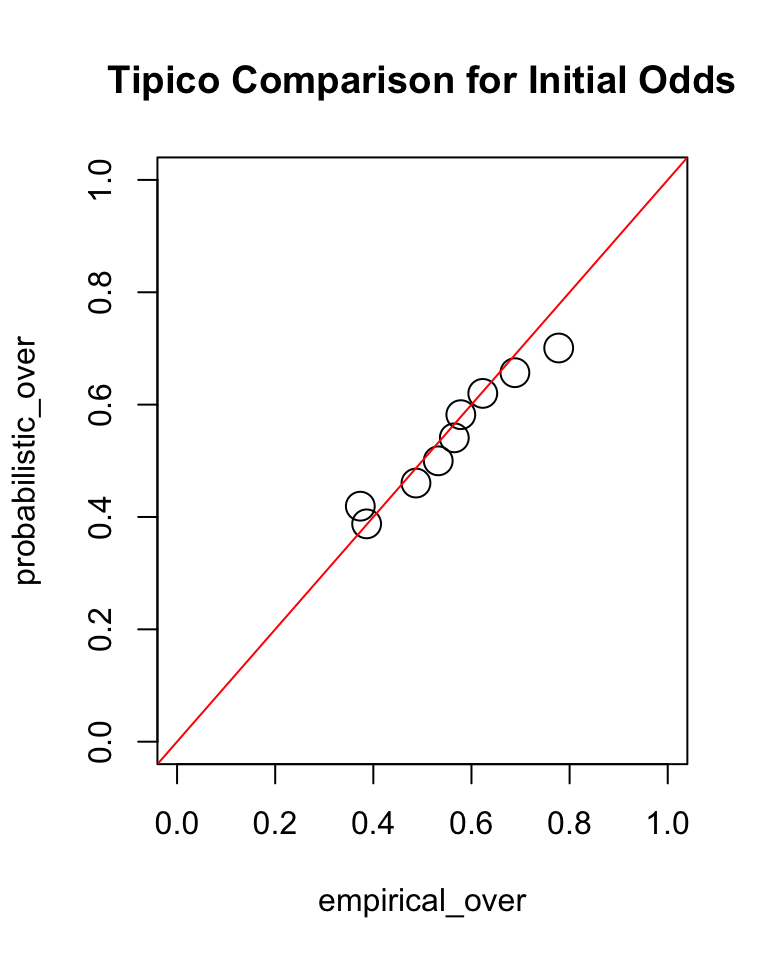

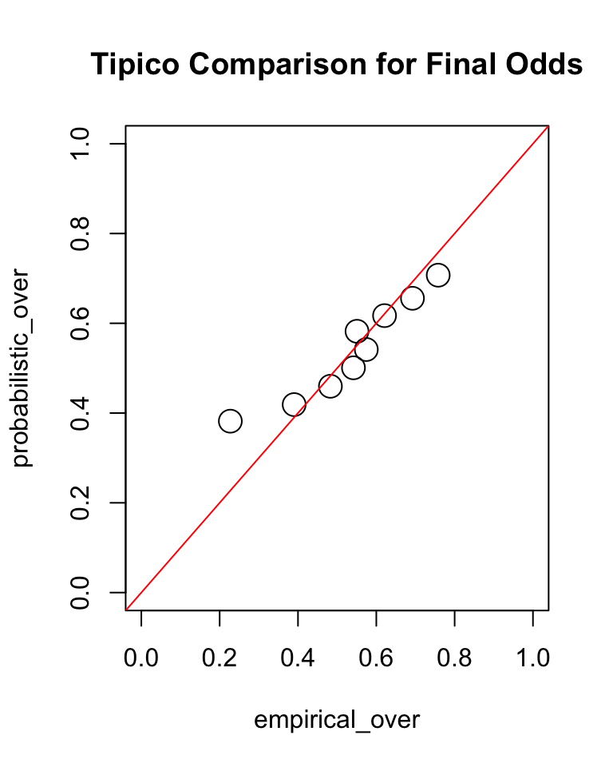

For the Tipico, there are more points in line with x=y line in the initial odds. This means that, their job quality decreases over time. In the final odds, there are also some outliers which shows their prediction is weak especially for the low probability intervals. For the intervals around 0.5, their probabilictic is lower than the empirical fraction in other words their profitability may decrease.

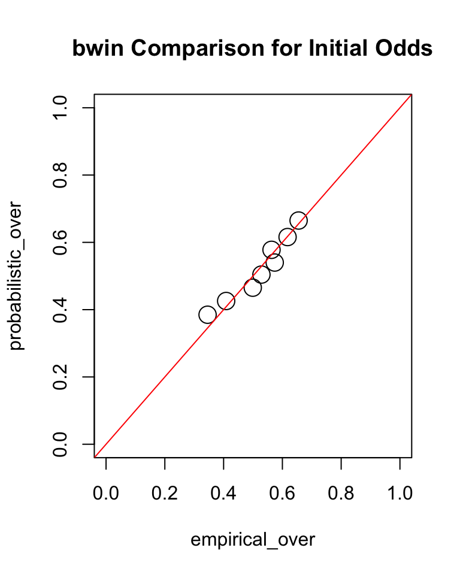

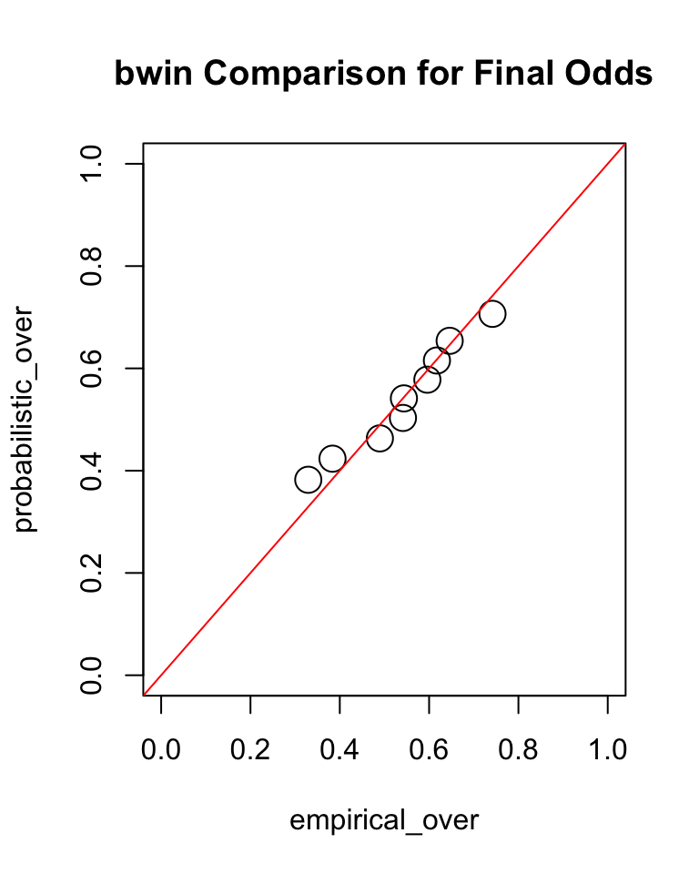

Most of the time, bwin makes great job; the points in the initial odds are mostly in line with x=y. However, they improves their odds’ accuracy and have more points in the final odds in line with x=y.

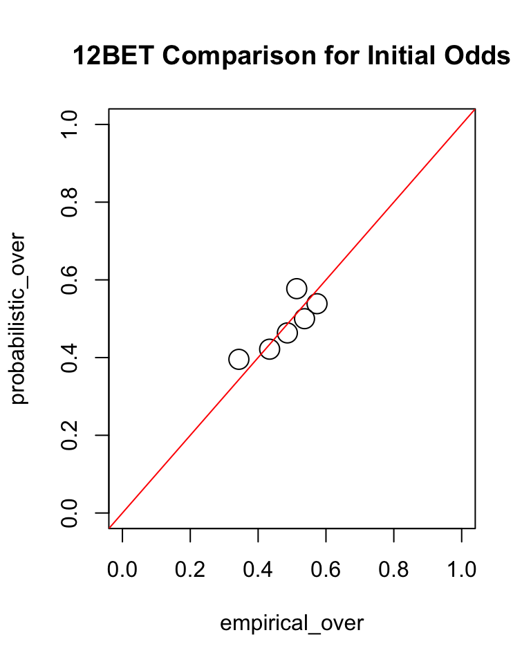

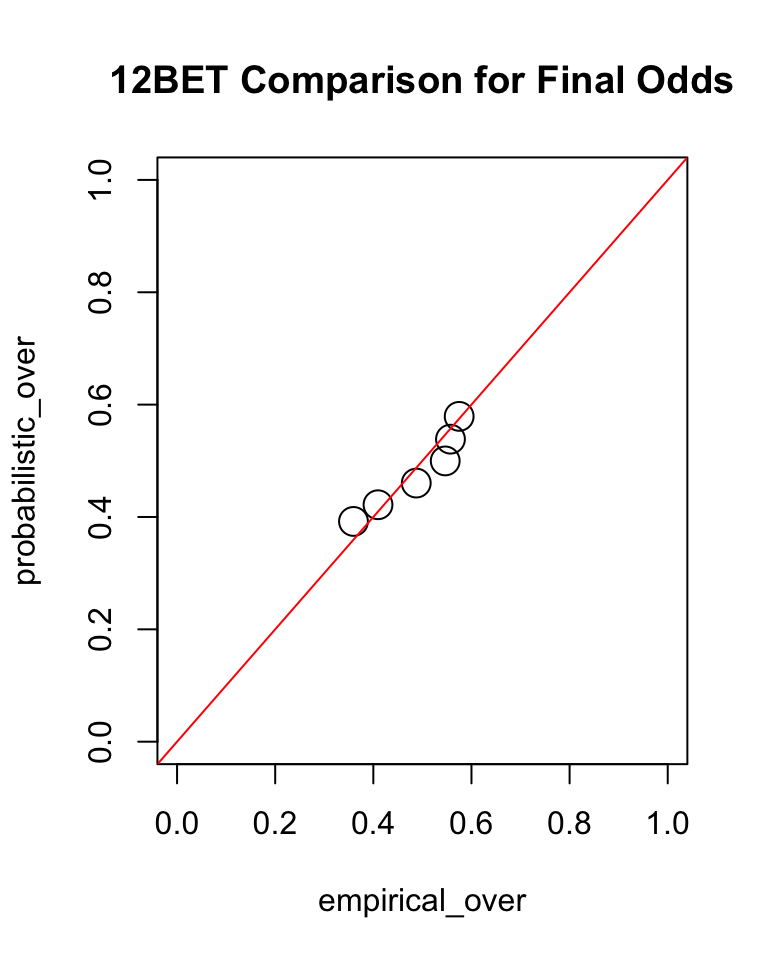

For the 12BET, there are two significant outliers in the initial odds graph. There are also more points on the right handside of x=y line which means they offer higher odds for low empirical over fractions. However, they improved their odds in the final odds. There are more points in line with x=y and there are not any outliers.

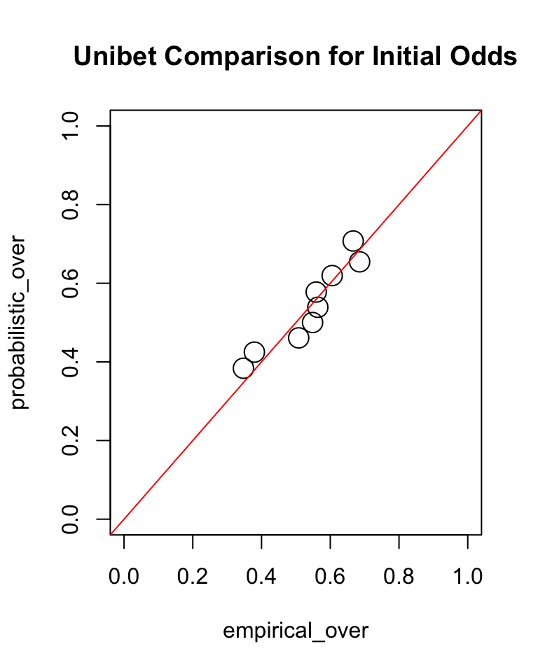

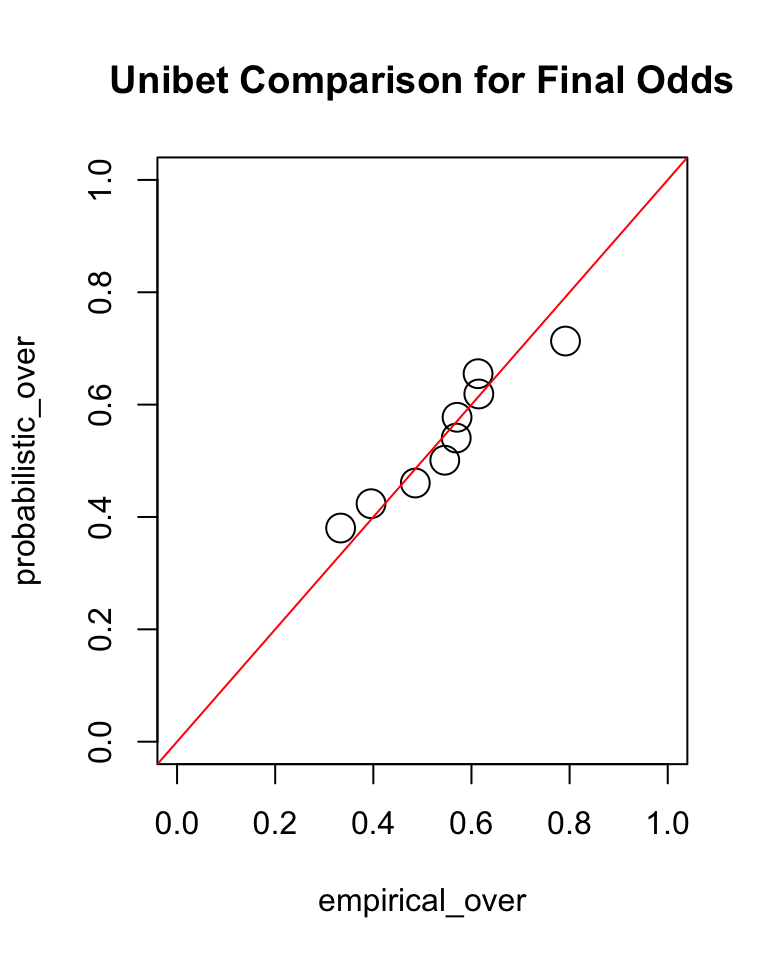

For the Unibet, the odds with around 0.5 probability are in line with empirical over fractions in the initial odds graph. However, there are some points not on the x=y line especially for odds with 0.4 and 0.75 probabilities. The situation becomes better in the final odds, however there is a significant outlier especially for over odds with around 0.75 probability.

## Part 1 - Section B - Performance of Bins Over Time

In this, SBOBET bookmaker is chosen and its initial odds performance is measured over the years. However, this examination is made for each bin separately to evaluate the performance in the each interval. For each bin, the probabilistic over and empirical over fractions are shown over the years. By looking that, it can be said that whether the bookmaker is consistently good at determining over probabilities or not.

To draw these graphs, following codes are used. Since part of the data tables (e.g SBOBET_merge_odds_match_i) are defined and operated before for the Section A, they are not provided here. The remaining required codes are provided as below:

```r
summary_table_b=SBOBET_merge_odds_match_i[,list(empirical_over = mean(IsOver),probabilistic_over = mean(ProbOver),.N), by=list(Year, odd_cut_over)]

summary_table_b=summary_table_b[order(Year)]
```

There is also a need for melting operation to plot these values in ggplot.

```r
melted_SBOBET = melt(summary_table_b,id.vars = c("Year", "odd_cut_over", "N"),
                     measure.vars = c("empirical_over","probabilistic_over"))
```

Recalling the discussion above, there are six bins for SBOBET which are (0.36,0.4], (0.4,0.44], (0.44,0.48],(0.48,0.52], (0.52,0.56] and (0.56,0.64]

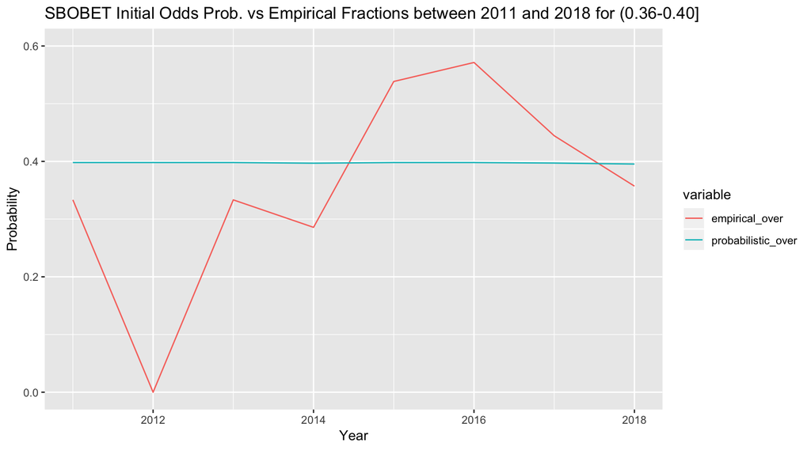

[figure not shown]

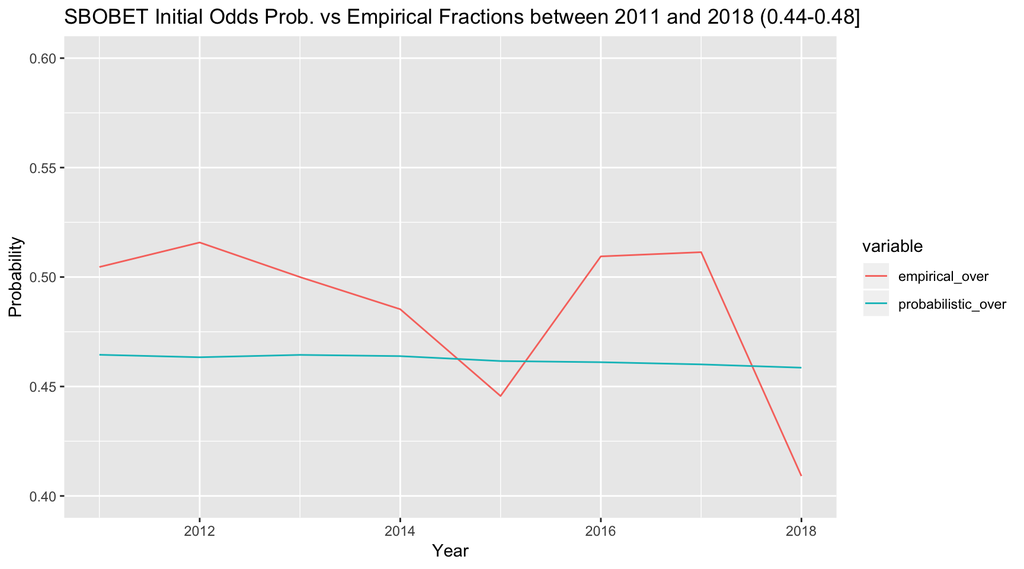

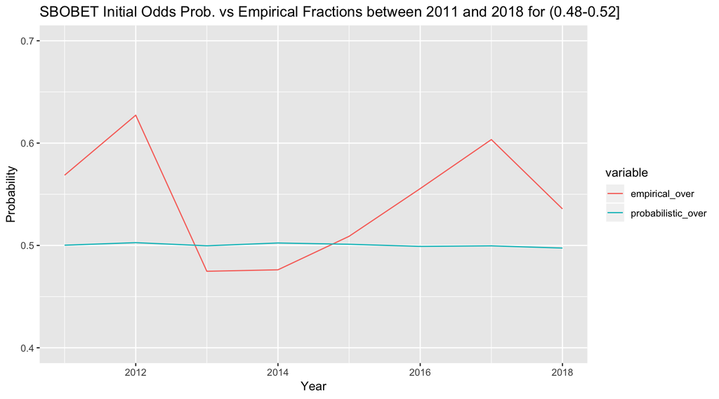

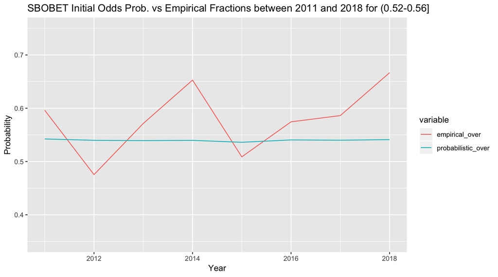

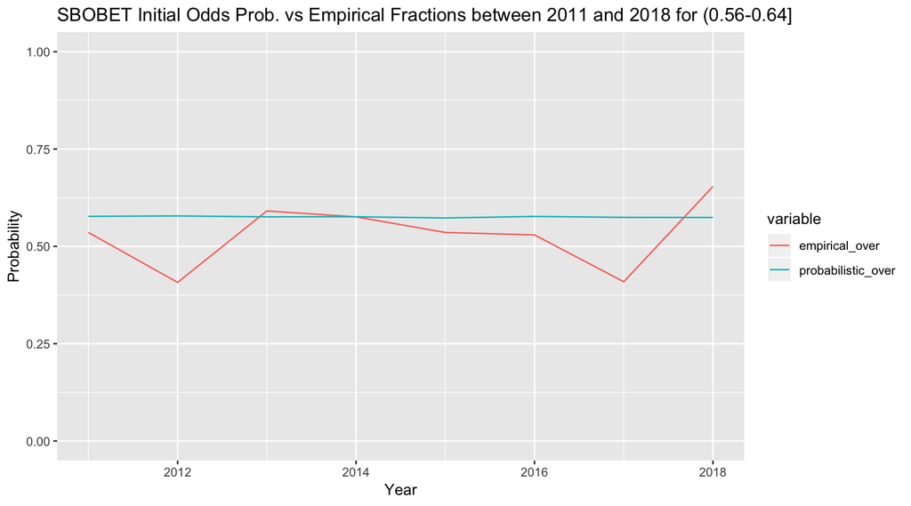

To be considered as consistently good at determining the odds over time period, the over probabilistic should follow the same path as empirical fractions. However, from most of the six graphs, it can be clearly seen that the empirical over fraction of the games in the corresponding bins oscillates frequently and the bookmaker cannot determine over probabilistic very good especially for the first years.

## Part 2 - Alternative Visualizations for 1X2

The football environment is so dynamic that the results of the matches can be easily affected from various changes. In that dynamic environment, the odds are also changing more frequently. There are two hypothesis needs to be supported.

**1)** The first hypothesis in this study suggests that football odds changes more especially in the last weeks (May) due to increase competition between teams to get championship for the teams in the higher ranking or avoid losing division for the teams in the lower ranking. Since the competition is high, the ability to determine probabilities would be harder and the bookmakers should reflect small changes in the teams.

**2)** The second hypothesis is that, the performances of teams hugely depend on players and the chemistry between these players since football is a team sport. The winter transfer seasons begins in January and ends in February. So, it is expected that the number of changes in odds should be high because of the incoming and outgoing players during the games are being played and the adaptation period.

In this study, again “SBOBET” bookmaker is chosen and its odds for “1x2” bettype are examined.

```r
odds_1x2_SBOBET=odds[betType=='1x2' & bookmaker=='SBOBET']
odds_1x2_SBOBET[,totalhandicap:=NULL]
odds_1x2_SBOBET = odds_1x2_SBOBET[order(matchId,date)]
```

Odds for 1x2 are converted to wide format and merged with matches data sets.

```r
odds_1x2_wide = dcast(odds_1x2_SBOBET, bookmaker + matchId + date ~oddtype , value.var='odd')
odds_1x2_wide = odds_1x2_wide[order(matchId,date)]
merge_odds1x2_match = merge(matches,odds_1x2_wide,by = 'matchId')
```

The data rearranged according to Months and MatchId to calculate total number of changes in the specific month for specific game

```r
summary_table_task_2 = merge_odds1x2_match[,list(count=.N),by=list(Month,matchId)]
```

To count total number of games in a specific month and total number of changes, the following codes are used:

```r
uniq=unique(summary_table_task_2[,matchId,by=list(Month)])
uniq_sum=unique(summary_table_task_2[,sum(count),by=list(Month)])
Month_matches = uniq[,list(count=.N),by = list(Month)] # total number of games in months (count unique matchIds)
merged_matches_changes = merge(Month_matches,uniq_sum, by = c('Month')) # merge the total number of changes and total number of games in the specific month
merged_matches_changes=merged_matches_changes[,Total_Change:=V1] # Change name of the V1 Column which keeps the Total change information
merged_matches_changes=merged_matches_changes[,V1:=NULL] # Delete the V1 columns since there is Total_Change column
```

Total change per game is calculated and ordered by months as follows:

```r
merged_matches_changes=merged_matches_changes[,TotalChangeperGame:=(Total_Change/count)]
merged_matches_changes = merged_matches_changes[order(Month)]
```

To exclude outliers, the thresold is set as 20 with the following code:

```r
merged_matches_changes=merged_matches_changes[TotalChangeperGame<20]
```

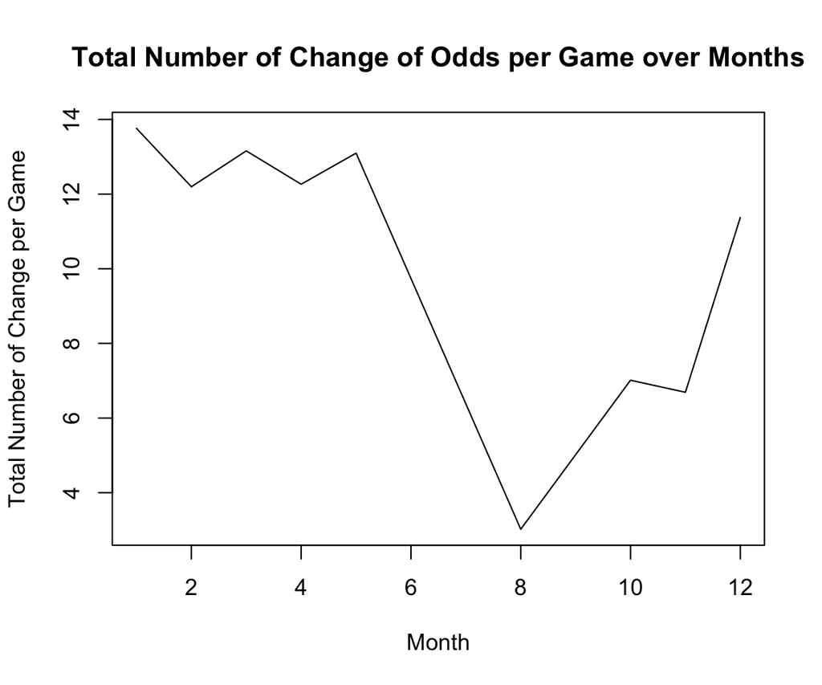

As it can be seen from the data, the total number of changes of Odds per game is high in the May (Month = 5) which supports the first hypothesis.